# R4DS 27_3 Text formatting

Gabriel

09/03/2022

This set of files are probably going to be done in R Markdown

Markdown is easy to read, write, and learn. Below is a quide of the Pandoc’s Markdown, which extends the basic R Markdown

## Text formatting

*italic* or *italic*, **bold** or **bold**, `code`, superscript<sup>2</sup> and subscript<sub>2</sub>,

# 1st Level Header

## 2nd Level Header

### 3rd Level Header

## Lists

- Bulleted list item 1
- Item 2
  - Item 2a
  - Item 2b
1. Numbered list item 1
2. Item 2. The numbers are incremented automatically in the output.

## Links and images

http://example.com

[linked phrase](http://example.com)

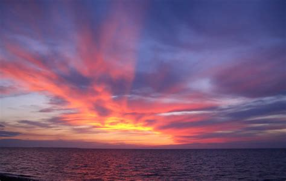

optional caption text

## Tables

| First Header | Second Header |
| --- | --- |
| Content Cell | Content Cell |
| Content Cell | Content Cell |

## Questions

### 1. Practice what you’ve learned by creating a brief CV. The title should be your name, and you should include headings for (at least) education or employment. Each of the sections should include a bulleted list of jobs/degrees. Highlight the year in bold.

## Education

### Twyford C of E High School

- 3 A* and 8 As at GCSE
- AAB A levels in Maths, Economics, and Photography. B in Chemistry AS and A in EPQ

### University of York

Integrated Master in Psychology, specialising in Neuroscience and Neuroimaging

## Employment

### Research Assistant, UoY Dep of Psychology - **Summer 2019**

- Oversaw data collection in an experiment for one of Dr Barraclough’s PhD students.
- Set-up the equipment, organised the participants and recorded the data.
- Learnt about experimental design in an unfamiliar area of psychology: emotional responses to music.
- Enjoyed getting to grips with different ways of undertaking research, and the specific equipment and programs used to record subjective and physical responses.
- Worked well with the participants, helping them to understand the experiment, solved problems that arose and ensured they had an enjoyable experience. This involved being friendly, helpful, and capable.

### Chalet Host, Ski Beat - **Winter 2017/8**

- Managed a chalet of 11 guests single-handedly, operating independently on a day-to-day basis. This involved being highly self-motivated, whilst also operating flexibly within the larger team in the resort. I learnt how to coordinate well with colleagues whilst being responsible for my own chalet without needing constant supervision.
- Dealt with guest’s queries and issues, developing my skills as an active listener and communicator.
- Planned, ordered, cooked, and served meals, which required excellent time management and organisation skills. I embraced challenging situations like cooking Christmas dinner for 12 while accommodating three separate food allergies.
- Learnt how to work under intense conditions and adapt quickly and effectively to changing circumstances e.g., snowstorms delaying food delivery.

## 2. Using the R Markdown quick reference, figure out how to:

### A) Add a footnote

The quick brown fox jumped over the lazy dog.[^1]

### C) Add a block quote

> Life is a journey. Time is a river. The door is ajar

> — Harry Dresden

## 3. Copy and paste the contents of diamond-sizes.Rmd from https://github.com/hadley/r4ds/tree/master/rmarkdown in to a local R markdown document. Check that you can run it, then add text after the frequency polygon that describes its most striking features

We have data about 53940 diamonds. Only 126 are larger than 2.5 carats. The distribution of the remainder is shown below:

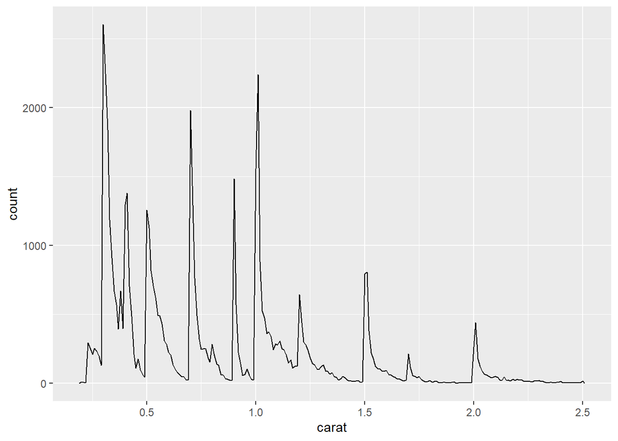

The most striking thing about the graph is how many diamonds are given round(ish) carats